# 2. Load source data

This vignettes require climate data from three different sources: TraCE21ka, UERRA, and CMIP5. Please follow `vignette("Data_downloading_and_preprocessing"")` before going on.

## TraCE21ka data

### Defining region limits for TraCE21ka data

```r
trace.lon <- c(-25, 25)
trace.lat <- c(25, 50)
```

### Loading TraCE21ka data

To load the TraCE21ka data for the historical period, we use the `dsclim::loadHistoricalTraceGrid` function. This function internally use functions from the `{loadeR}` package. This function require the file (including the path to the file) and the variable name (as it is specified in the data dictionary for standardization). Optionally, the spatial coverage can be controlled, specifying an extent by the longitudinal and latitudinal extents. The function also allow to specify the starting and ending year of the desired period. If not specified, it uses the period 1961 to 1990, both years included.

Once the data are loaded, we used the `transformeR::climatology` function to calculate the average value of the variable for the whole period (e.g. 1961-1990) and the `visualizeR::spatialPlot` to plot the resulting map.

Select a variable:

#### TSMX

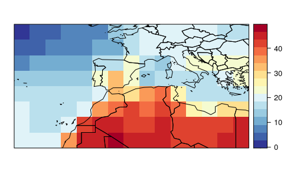

TraCE21ka historical tsmx

```r
trace.tsmx <- dsclim::loadHistoricalTraceGrid("Data/TraCE21ka/TSMX/trace.36.400BP-1990CE.cam2.h0.TSMX.2160101-2204012.nc", var="tasmax", lonLim=trace.lon, latLim = trace.lat)

visualizeR::spatialPlot(transformeR::climatology(trace.tsmx), backdrop.theme = "countries", rev.colors=TRUE)
```

#### TSMN

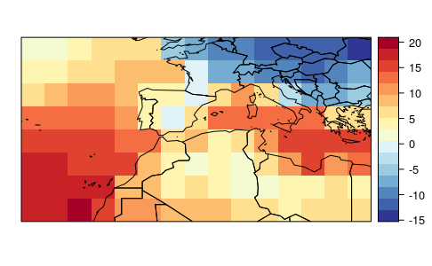

TraCE21ka historical tsmn

```r
trace.tsmn <- dsclim::loadHistoricalTraceGrid("Data/TraCE21ka/TSMN/trace.36.400BP-1990CE.cam2.h0.TSMN.2160101-2204012.nc", var="tasmin", lonLim=trace.lon, latLim = trace.lat)

visualizeR::spatialPlot(transformeR::climatology(trace.tsmn), backdrop.theme = "countries", rev.colors=TRUE)
```

#### TS

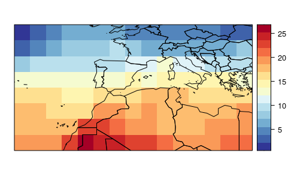

TraCE21ka historical ts

```r
trace.ts <- dsclim::loadHistoricalTraceGrid("Data/TraCE21ka/TS/trace.36.400BP-1990CE.cam2.h0.TS.2160101-2204012.nc", var="tas", lonLim=trace.lon, latLim = trace.lat)

visualizeR::spatialPlot(transformeR::climatology(trace.ts), backdrop.theme = "countries", rev.colors=TRUE)
```

#### PRECC

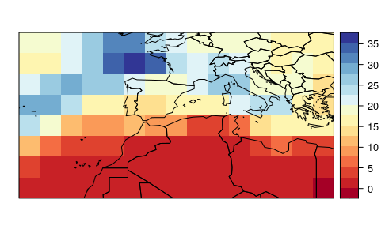

TraCE21ka historical pr

```r
trace.precc <- dsclim::loadHistoricalTraceGrid("Data/TraCE21ka/PRECC/trace.36.400BP-1990CE.cam2.h0.PRECC.2160101-2204012.nc", var="pr", lonLim=trace.lon, latLim = trace.lat)

visualizeR::spatialPlot(transformeR::climatology(trace.precc), backdrop.theme = "countries")
```

#### RELHUM

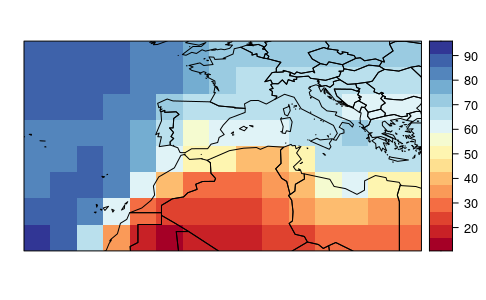

TraCE21ka historical rhum

```r
trace.relhum <- dsclim::loadHistoricalTraceGrid("Data/TraCE21ka/RELHUM/trace.36.400BP-1990CE.cam2.h0.RELHUM.2160101-2204012.nc", var="hurs@992.5561", lonLim=trace.lon, latLim = trace.lat)

visualizeR::spatialPlot(transformeR::climatology(trace.relhum), backdrop.theme = "countries")
```

#### CLDTOT

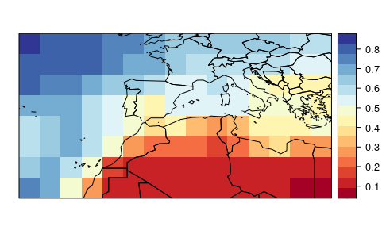

TraCE21ka historical cld

```r
trace.cldtot <- dsclim::loadHistoricalTraceGrid("Data/TraCE21ka/CLDTOT/trace.36.400BP-1990CE.cam2.h0.CLDTOT.2160101-2204012.nc", var="cld", lonLim=trace.lon, latLim = trace.lat)

visualizeR::spatialPlot(transformeR::climatology(trace.cldtot), backdrop.theme = "countries")
```

#### PS

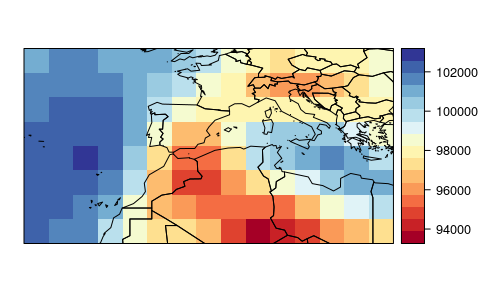

TraCE21ka historical ps

```r
trace.ps <- dsclim::loadHistoricalTraceGrid("Data/TraCE21ka/PS/trace.36.400BP-1990CE.cam2.h0.PS.2160101-2204012.nc", var="ps", lonLim=trace.lon, latLim = trace.lat)

visualizeR::spatialPlot(transformeR::climatology(trace.ps), backdrop.theme = "countries")
```

#### U

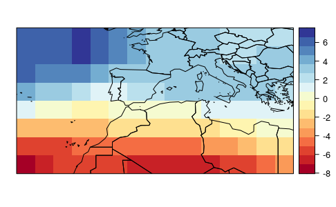

TraCE21ka historical u

```r
trace.u <- dsclim::loadHistoricalTraceGrid("Data/TraCE21ka/U/trace.36.400BP-1990CE.cam2.h0.U.2160101-2204012.nc", var="u@992.5561", lonLim=trace.lon, latLim = trace.lat)

visualizeR::spatialPlot(transformeR::climatology(trace.u), backdrop.theme = "countries")
```

#### V

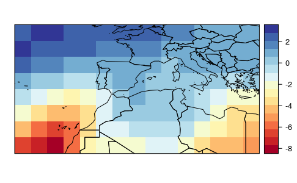

TraCE21ka historical v

```r
trace.v <- dsclim::loadHistoricalTraceGrid("Data/TraCE21ka/V/trace.36.400BP-1990CE.cam2.h0.V.2160101-2204012.nc", var="v@992.5561", lonLim=trace.lon, latLim = trace.lat)

visualizeR::spatialPlot(transformeR::climatology(trace.v), backdrop.theme = "countries")
```

#### WSS

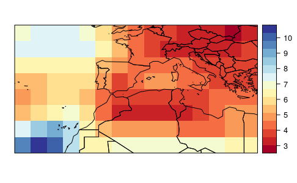

TraCE21ka historical wss

```r
trace.wss <- dsclim::compute_wind_speed(trace.u, trace.v)

visualizeR::spatialPlot(transformeR::climatology(trace.wss), backdrop.theme = "countries")
```

### Make multivariable grid

[figure not shown]

TraCE21ka historical

```r
hist.trace <- transformeR::makeMultiGrid(trace.tsmx, trace.tsmn, trace.ts, trace.precc, trace.relhum, trace.cldtot, trace.ps, trace.wss)

rm(trace.tsmx, trace.tsmn, trace.ts, trace.precc, trace.relhum, trace.cldtot, trace.ps, trace.wss, trace.u, trace.v)

visualizeR::spatialPlot(transformeR::climatology(hist.trace), backdrop.theme = "countries")
```

## UERRA historical reanalisis data

Now, we are ready to import the files in R and check them out with the `climate4r` framework. More specifically, we are using the `loadeR` and `visualizeR` packages.

### Defining region limits for UERRA data

```r
uerra.lon <- c(-11, 12)
uerra.lat <- c(28, 44)
# uerra.lon <- c(-11, 4)
# uerra.lat <- c(36, 44)
```

### Loading UERRA data

Select a variable

#### TASMIN

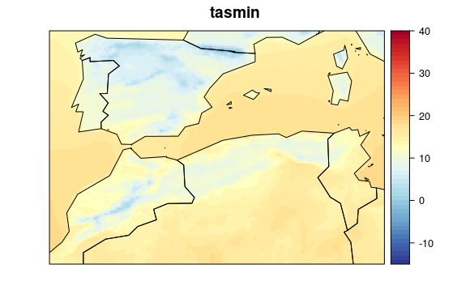

UERRA tasmin

```r
uerra.tasmin <- loadeR::loadGridData("Data/UERRA/UERRA-HARMONIE/2m_temperature/latlon/1961-90_2m_tmin.nc", var = "tasmin", lonLim = uerra.lon, latLim = uerra.lat, dictionary = "Data/UERRA/UERRA_dictionary.dic")

visualizeR::spatialPlot(transformeR::climatology(uerra.tasmin), main="tasmin", backdrop.theme="countries", rev.colors=TRUE, at=seq(-15,40,1))
```

#### TAS

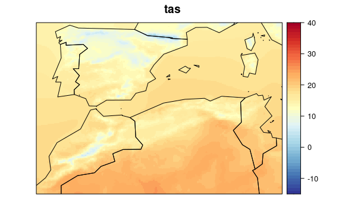

UERRA tas

```r
uerra.tas <- loadeR::loadGridData("Data/UERRA/UERRA-HARMONIE/2m_temperature/latlon/1961-90_2m_temperature.nc", var = "tas", lonLim = uerra.lon, latLim = uerra.lat, dictionary="Data/UERRA/UERRA_dictionary.dic")

visualizeR::spatialPlot(transformeR::climatology(uerra.tas), main="tas", backdrop.theme="countries", rev.colors=TRUE, at=seq(-15,40,1))
```

#### TASMAX

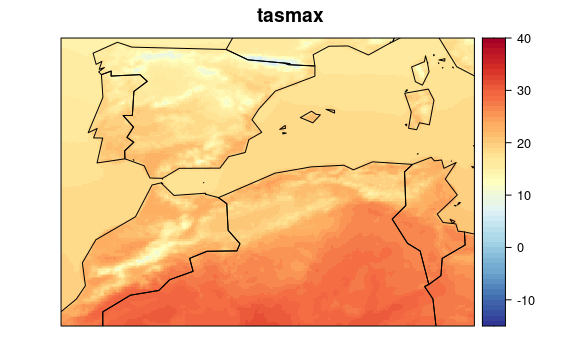

UERRA tasmax

```r
uerra.tasmax <- loadeR::loadGridData("Data/UERRA/UERRA-HARMONIE/2m_temperature/latlon/1961-90_2m_tmax.nc", var = "tasmax", lonLim = uerra.lon, latLim = uerra.lat, dictionary="Data/UERRA/UERRA_dictionary.dic")

visualizeR::spatialPlot(transformeR::climatology(uerra.tasmax), main="tasmax", backdrop.theme="countries", rev.colors=TRUE, at=seq(-15,40,1))
```

#### PR

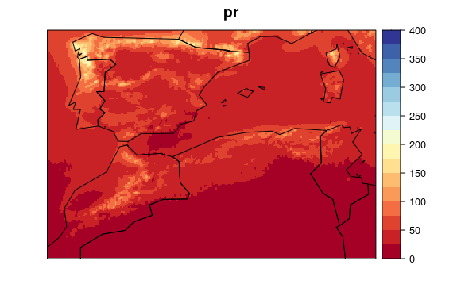

UERRA pr

```r
uerra.pr <- loadeR::loadGridData("Data/UERRA/MESCAN-SURFEX/total_precipitation/latlon/1961-90_total_precipitation.nc", var = "pr", lonLim = uerra.lon, latLim = uerra.lat, dictionary = "Data/UERRA/UERRA_dictionary.dic")

uerra.pr <- transformeR::upscaleGrid(uerra.pr, times = 2, aggr.fun = list(FUN = mean))

uerra.pr <- transformeR::interpGrid(uerra.pr, new.coordinates = transformeR::getGrid(uerra.tas), method="bilinear")

visualizeR::spatialPlot(transformeR::climatology(uerra.pr), main = "pr", backdrop.theme = "countries", at = seq(0,400,25))
```

#### HURS

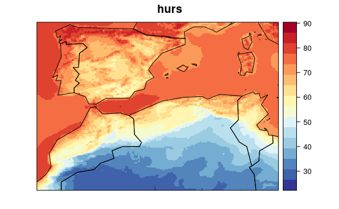

UERRA rhum

```r
uerra.hurs <- loadeR::loadGridData("Data/UERRA/UERRA-HARMONIE/2m_relative_humidity/latlon/1961-90_2m_relative_humidity.nc", var = "hurs", lonLim = uerra.lon, latLim = uerra.lat, dictionary = "Data/UERRA/UERRA_dictionary.dic")

visualizeR::spatialPlot(transformeR::climatology(uerra.hurs), main="hurs", backdrop.theme="countries", rev.colors=TRUE)
```

#### PS

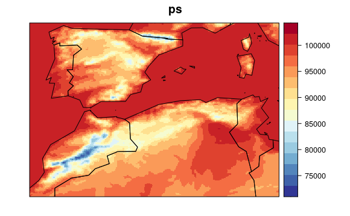

UERRA ps

```r
uerra.ps <- loadeR::loadGridData("Data/UERRA/UERRA-HARMONIE/surface_pressure/latlon/1961-90_surface_pressure.nc", var = "ps", lonLim = uerra.lon, latLim = uerra.lat, dictionary = "Data/UERRA/UERRA_dictionary.dic")

visualizeR::spatialPlot(transformeR::climatology(uerra.ps), main="ps", backdrop.theme="countries", rev.colors=TRUE)
```

#### CLD

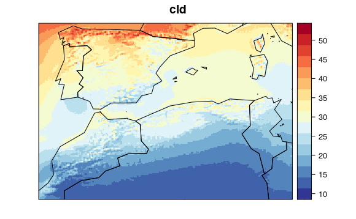

UERRA cld

```r
uerra.cld <- loadeR::loadGridData("Data/UERRA/UERRA-HARMONIE/total_cloud_cover/latlon/1961-90_total_cloud_cover.nc", var = "cld", lonLim = uerra.lon, latLim = uerra.lat, dictionary = "Data/UERRA/UERRA_dictionary.dic")

visualizeR::spatialPlot(transformeR::climatology(uerra.cld), main="cld", backdrop.theme="countries", rev.colors=TRUE)
```

#### WSS

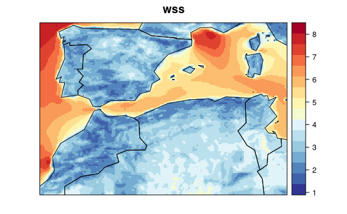

UERRA wss

```r
uerra.wss <- loadeR::loadGridData("Data/UERRA/UERRA-HARMONIE/10m_wind_speed/latlon/1961-90_10m_wind_speed.nc", var = "wss", lonLim = uerra.lon, latLim = uerra.lat, dictionary = "Data/UERRA/UERRA_dictionary.dic")

visualizeR::spatialPlot(transformeR::climatology(uerra.wss), main="wss", backdrop.theme="countries", rev.colors=TRUE)
```

### Fix dates

Dates from the UERRA files match the actual year and month, but are interpreted as the central date of the month, rather than the whole range of data. The `modifyDates` function from the `dsclim` package modify the dates and fix this small issue.

```r
uerra.tasmax <- modifyDates(uerra.tasmax)
uerra.tasmin <- modifyDates(uerra.tasmin)
uerra.tas <- modifyDates(uerra.tas)
uerra.pr <- modifyDates(uerra.pr)
uerra.hurs <- modifyDates(uerra.hurs)
uerra.cld <- modifyDates(uerra.cld)
uerra.wss <- modifyDates(uerra.wss)
```